# 578hw3

## 578hw3.ipynb

### CSC 578 Neural Networks and Deep Learning

### HW3: Implementation of Neural Networks

```python
import NN578_network as network
import numpy as np

import warnings
warnings.filterwarnings("ignore")
```

```python
# Load the dataset (already in the 'one-hot-vector' format for the target)
# Call the function to load the data.
iris_data = network.my_load_csv('iris.csv', 4, 3)
```

```python
# Create a network from the saved network
net1 = network.load_network("iris-423.dat")
```

#### Part 3: Further Application and Testing

First, train the net1 network (created in the initial steps of the "start-up file" from iris-423.dat) by training it on the iris data (iris.csv) by calling SGD() for a maximum of 100 epochs, minibatch_size=5, eta=0.5. No specific value should be passed in for stopaccuracy to take the default (1.0).

```python
training_results = net1.SGD(iris_data, 100, 5, 0.5)
```

```
[Epoch 0] Training: MSE=0.33989623, CE=1.93947802, LL=1.07270335, Correct=50/150, Acc=0.3333333333333333
[Epoch 1] Training: MSE=0.35054136, CE=1.98910892, LL=1.13654524, Correct=50/150, Acc=0.3333333333333333
[Epoch 2] Training: MSE=0.33898723, CE=1.93723493, LL=1.12030613, Correct=50/150, Acc=0.3333333333333333
[Epoch 3] Training: MSE=0.30402667, CE=1.76598458, LL=0.98309968, Correct=51/150, Acc=0.34
[Epoch 4] Training: MSE=0.27946742, CE=1.65306466, LL=0.88038172, Correct=100/150, Acc=0.6666666666666666
[Epoch 5] Training: MSE=0.25916154, CE=1.56196374, LL=0.80792403, Correct=100/150, Acc=0.6666666666666666
[Epoch 6] Training: MSE=0.24333059, CE=1.48939578, LL=0.75466382, Correct=100/150, Acc=0.6666666666666666
[Epoch 7] Training: MSE=0.23153034, CE=1.43260666, LL=0.71520737, Correct=100/150, Acc=0.6666666666666666
[Epoch 8] Training: MSE=0.22283392, CE=1.38810432, LL=0.68570972, Correct=100/150, Acc=0.6666666666666666
[Epoch 9] Training: MSE=0.2163863, CE=1.35286947, LL=0.6633247, Correct=100/150, Acc=0.6666666666666666
[Epoch 10] Training: MSE=0.21155054, CE=1.32462457, LL=0.64601912, Correct=100/150, Acc=0.6666666666666666
[Epoch 11] Training: MSE=0.2078908, CE=1.30174644, LL=0.63237556, Correct=100/150, Acc=0.6666666666666666
[Epoch 12] Training: MSE=0.20511694, CE=1.28309614, LL=0.62141506, Correct=100/150, Acc=0.6666666666666666
[Epoch 13] Training: MSE=0.2030293, CE=1.26784584, LL=0.61246681, Correct=100/150, Acc=0.6666666666666666
[Epoch 14] Training: MSE=0.20147235, CE=1.25532061, LL=0.60507322, Correct=100/150, Acc=0.6666666666666666
[Epoch 15] Training: MSE=0.20030105, CE=1.24486556, LL=0.59890049, Correct=100/150, Acc=0.6666666666666666
[Epoch 16] Training: MSE=0.19936157, CE=1.23573475, LL=0.59362044, Correct=100/150, Acc=0.6666666666666666
[Epoch 17] Training: MSE=0.19846286, CE=1.2268636, LL=0.58868507, Correct=100/150, Acc=0.6666666666666666
[Epoch 18] Training: MSE=0.19720532, CE=1.21573647, LL=0.58262039, Correct=100/150, Acc=0.6666666666666666
[Epoch 19] Training: MSE=0.19438939, CE=1.19440802, LL=0.57068463, Correct=100/150, Acc=0.6666666666666666
[Epoch 20] Training: MSE=0.19092608, CE=1.16732717, LL=0.55286608, Correct=100/150, Acc=0.6666666666666666
[Epoch 21] Training: MSE=0.19096008, CE=1.16133018, LL=0.54312471, Correct=100/150, Acc=0.6666666666666666
[Epoch 22] Training: MSE=0.19353066, CE=1.16929236, LL=0.53927297, Correct=100/150, Acc=0.6666666666666666
[Epoch 23] Training: MSE=0.19776431, CE=1.18560542, LL=0.54036904, Correct=100/150, Acc=0.6666666666666666
[Epoch 24] Training: MSE=0.20178627, CE=1.20164379, LL=0.54486505, Correct=100/150, Acc=0.6666666666666666
[Epoch 25] Training: MSE=0.20662471, CE=1.22178025, LL=0.54960066, Correct=100/150, Acc=0.6666666666666666
[Epoch 26] Training: MSE=0.21241592, CE=1.24698192, LL=0.55558579, Correct=100/150, Acc=0.6666666666666666
[Epoch 27] Training: MSE=0.22371923, CE=1.30062268, LL=0.56667376, Correct=100/150, Acc=0.6666666666666666
[Epoch 28] Training: MSE=0.24331341, CE=1.40561068, LL=0.59374334, Correct=100/150, Acc=0.6666666666666666
[Epoch 29] Training: MSE=0.24199777, CE=1.39912289, LL=0.59138124, Correct=100/150, Acc=0.6666666666666666
[Epoch 30] Training: MSE=0.2394687, CE=1.38389155, LL=0.59045876, Correct=100/150, Acc=0.6666666666666666
[Epoch 31] Training: MSE=0.23599222, CE=1.36317079, LL=0.58667198, Correct=100/150, Acc=0.6666666666666666
[Epoch 32] Training: MSE=0.23289589, CE=1.3447019, LL=0.58358964, Correct=100/150, Acc=0.6666666666666666
[Epoch 33] Training: MSE=0.23009235, CE=1.3281446, LL=0.58092824, Correct=100/150, Acc=0.6666666666666666
[Epoch 34] Training: MSE=0.22722565, CE=1.31165773, LL=0.57818266, Correct=100/150, Acc=0.6666666666666666
[Epoch 35] Training: MSE=0.22334286, CE=1.29038726, LL=0.57330663, Correct=100/150, Acc=0.6666666666666666
[Epoch 36] Training: MSE=0.22467301, CE=1.29779632, LL=0.57115706, Correct=100/150, Acc=0.6666666666666666
[Epoch 37] Training: MSE=0.22330533, CE=1.29038782, LL=0.56749807, Correct=100/150, Acc=0.6666666666666666
[Epoch 38] Training: MSE=0.22251684, CE=1.28617554, LL=0.56502888, Correct=100/150, Acc=0.6666666666666666
[Epoch 39] Training: MSE=0.22101269, CE=1.27807819, LL=0.56246911, Correct=100/150, Acc=0.6666666666666666
```

[output cut: 45 more lines]

```
[Epoch 85] Training: MSE=0.09664843, CE=0.66447854, LL=0.30887734, Correct=131/150, Acc=0.8733333333333333
[Epoch 86] Training: MSE=0.09450248, CE=0.65351008, LL=0.30381584, Correct=131/150, Acc=0.8733333333333333
[Epoch 87] Training: MSE=0.09252367, CE=0.64333064, LL=0.29912918, Correct=131/150, Acc=0.8733333333333333
[Epoch 88] Training: MSE=0.09065901, CE=0.63368593, LL=0.29469877, Correct=131/150, Acc=0.8733333333333333
[Epoch 89] Training: MSE=0.08882565, CE=0.62417564, LL=0.2903317, Correct=131/150, Acc=0.8733333333333333
[Epoch 90] Training: MSE=0.08696792, CE=0.61453152, LL=0.28589242, Correct=131/150, Acc=0.8733333333333333
[Epoch 91] Training: MSE=0.08507876, CE=0.60472286, LL=0.28135439, Correct=131/150, Acc=0.8733333333333333
[Epoch 92] Training: MSE=0.08320521, CE=0.59498389, LL=0.27681506, Correct=133/150, Acc=0.8866666666666667
[Epoch 93] Training: MSE=0.08142377, CE=0.58569286, LL=0.27244386, Correct=133/150, Acc=0.8866666666666667
[Epoch 94] Training: MSE=0.07979103, CE=0.57712893, LL=0.26837303, Correct=133/150, Acc=0.8866666666666667
[Epoch 95] Training: MSE=0.07831577, CE=0.56933537, LL=0.26463285, Correct=133/150, Acc=0.8866666666666667
[Epoch 96] Training: MSE=0.07697374, CE=0.56219254, LL=0.26118019, Correct=134/150, Acc=0.8933333333333333
[Epoch 97] Training: MSE=0.07573288, CE=0.55554221, LL=0.25795193, Correct=135/150, Acc=0.9
[Epoch 98] Training: MSE=0.07456498, CE=0.54924517, LL=0.25489053, Correct=136/150, Acc=0.9066666666666666
[Epoch 99] Training: MSE=0.07344778, CE=0.54319159, LL=0.25194933, Correct=136/150, Acc=0.9066666666666666
```

```python
# Create a network from the saved network
net2= network.load_network("iris-423.dat")
```

```python
#additionally with stopaccuracy=0.75
training_results_2 = net2.SGD(iris_data, 100, 5, 0.5,stopaccuracy=0.75)
```

```
[Epoch 0] Training: MSE=0.33989623, CE=1.93947802, LL=1.07270335, Correct=50/150, Acc=0.3333333333333333
[Epoch 1] Training: MSE=0.35054136, CE=1.98910892, LL=1.13654524, Correct=50/150, Acc=0.3333333333333333
[Epoch 2] Training: MSE=0.33898723, CE=1.93723493, LL=1.12030613, Correct=50/150, Acc=0.3333333333333333
[Epoch 3] Training: MSE=0.30402667, CE=1.76598458, LL=0.98309968, Correct=51/150, Acc=0.34
[Epoch 4] Training: MSE=0.27946742, CE=1.65306466, LL=0.88038172, Correct=100/150, Acc=0.6666666666666666
[Epoch 5] Training: MSE=0.25916154, CE=1.56196374, LL=0.80792403, Correct=100/150, Acc=0.6666666666666666
[Epoch 6] Training: MSE=0.24333059, CE=1.48939578, LL=0.75466382, Correct=100/150, Acc=0.6666666666666666
[Epoch 7] Training: MSE=0.23153034, CE=1.43260666, LL=0.71520737, Correct=100/150, Acc=0.6666666666666666
[Epoch 8] Training: MSE=0.22283392, CE=1.38810432, LL=0.68570972, Correct=100/150, Acc=0.6666666666666666
[Epoch 9] Training: MSE=0.2163863, CE=1.35286947, LL=0.6633247, Correct=100/150, Acc=0.6666666666666666
[Epoch 10] Training: MSE=0.21155054, CE=1.32462457, LL=0.64601912, Correct=100/150, Acc=0.6666666666666666
[Epoch 11] Training: MSE=0.2078908, CE=1.30174644, LL=0.63237556, Correct=100/150, Acc=0.6666666666666666
[Epoch 12] Training: MSE=0.20511694, CE=1.28309614, LL=0.62141506, Correct=100/150, Acc=0.6666666666666666
[Epoch 13] Training: MSE=0.2030293, CE=1.26784584, LL=0.61246681, Correct=100/150, Acc=0.6666666666666666
[Epoch 14] Training: MSE=0.20147235, CE=1.25532061, LL=0.60507322, Correct=100/150, Acc=0.6666666666666666
[Epoch 15] Training: MSE=0.20030105, CE=1.24486556, LL=0.59890049, Correct=100/150, Acc=0.6666666666666666
[Epoch 16] Training: MSE=0.19936157, CE=1.23573475, LL=0.59362044, Correct=100/150, Acc=0.6666666666666666
[Epoch 17] Training: MSE=0.19846286, CE=1.2268636, LL=0.58868507, Correct=100/150, Acc=0.6666666666666666
[Epoch 18] Training: MSE=0.19720532, CE=1.21573647, LL=0.58262039, Correct=100/150, Acc=0.6666666666666666
[Epoch 19] Training: MSE=0.19438939, CE=1.19440802, LL=0.57068463, Correct=100/150, Acc=0.6666666666666666
[Epoch 20] Training: MSE=0.19092608, CE=1.16732717, LL=0.55286608, Correct=100/150, Acc=0.6666666666666666
[Epoch 21] Training: MSE=0.19096008, CE=1.16133018, LL=0.54312471, Correct=100/150, Acc=0.6666666666666666
[Epoch 22] Training: MSE=0.19353066, CE=1.16929236, LL=0.53927297, Correct=100/150, Acc=0.6666666666666666
[Epoch 23] Training: MSE=0.19776431, CE=1.18560542, LL=0.54036904, Correct=100/150, Acc=0.6666666666666666
[Epoch 24] Training: MSE=0.20178627, CE=1.20164379, LL=0.54486505, Correct=100/150, Acc=0.6666666666666666
[Epoch 25] Training: MSE=0.20662471, CE=1.22178025, LL=0.54960066, Correct=100/150, Acc=0.6666666666666666
[Epoch 26] Training: MSE=0.21241592, CE=1.24698192, LL=0.55558579, Correct=100/150, Acc=0.6666666666666666
[Epoch 27] Training: MSE=0.22371923, CE=1.30062268, LL=0.56667376, Correct=100/150, Acc=0.6666666666666666
[Epoch 28] Training: MSE=0.24331341, CE=1.40561068, LL=0.59374334, Correct=100/150, Acc=0.6666666666666666
[Epoch 29] Training: MSE=0.24199777, CE=1.39912289, LL=0.59138124, Correct=100/150, Acc=0.6666666666666666
[Epoch 30] Training: MSE=0.2394687, CE=1.38389155, LL=0.59045876, Correct=100/150, Acc=0.6666666666666666
[Epoch 31] Training: MSE=0.23599222, CE=1.36317079, LL=0.58667198, Correct=100/150, Acc=0.6666666666666666
[Epoch 32] Training: MSE=0.23289589, CE=1.3447019, LL=0.58358964, Correct=100/150, Acc=0.6666666666666666
[Epoch 33] Training: MSE=0.23009235, CE=1.3281446, LL=0.58092824, Correct=100/150, Acc=0.6666666666666666
[Epoch 34] Training: MSE=0.22722565, CE=1.31165773, LL=0.57818266, Correct=100/150, Acc=0.6666666666666666
[Epoch 35] Training: MSE=0.22334286, CE=1.29038726, LL=0.57330663, Correct=100/150, Acc=0.6666666666666666
[Epoch 36] Training: MSE=0.22467301, CE=1.29779632, LL=0.57115706, Correct=100/150, Acc=0.6666666666666666
[Epoch 37] Training: MSE=0.22330533, CE=1.29038782, LL=0.56749807, Correct=100/150, Acc=0.6666666666666666
[Epoch 38] Training: MSE=0.22251684, CE=1.28617554, LL=0.56502888, Correct=100/150, Acc=0.6666666666666666
[Epoch 39] Training: MSE=0.22101269, CE=1.27807819, LL=0.56246911, Correct=100/150, Acc=0.6666666666666666
```

[output cut: 11 more lines]

```
[Epoch 51] Training: MSE=0.2058519, CE=1.20331541, LL=0.52882492, Correct=102/150, Acc=0.68
[Epoch 52] Training: MSE=0.20493768, CE=1.19855574, LL=0.52753879, Correct=102/150, Acc=0.68
[Epoch 53] Training: MSE=0.20367382, CE=1.19199722, LL=0.52569989, Correct=102/150, Acc=0.68
[Epoch 54] Training: MSE=0.20210133, CE=1.18388439, LL=0.52332046, Correct=102/150, Acc=0.68
[Epoch 55] Training: MSE=0.20017765, CE=1.17402428, LL=0.52031668, Correct=103/150, Acc=0.6866666666666666
[Epoch 56] Training: MSE=0.19791986, CE=1.16253436, LL=0.51673089, Correct=103/150, Acc=0.6866666666666666
[Epoch 57] Training: MSE=0.19535639, CE=1.14958619, LL=0.51262232, Correct=103/150, Acc=0.6866666666666666
[Epoch 58] Training: MSE=0.19251818, CE=1.13535662, LL=0.508037, Correct=104/150, Acc=0.6933333333333334
[Epoch 59] Training: MSE=0.18943311, CE=1.11999754, LL=0.50299692, Correct=105/150, Acc=0.7
[Epoch 60] Training: MSE=0.18612719, CE=1.10364146, LL=0.49751024, Correct=107/150, Acc=0.7133333333333334
[Epoch 61] Training: MSE=0.1826249, CE=1.08640345, LL=0.49158036, Correct=108/150, Acc=0.72
[Epoch 62] Training: MSE=0.17894371, CE=1.06835637, LL=0.4852018, Correct=109/150, Acc=0.7266666666666667
[Epoch 63] Training: MSE=0.17508312, CE=1.04947938, LL=0.47834243, Correct=111/150, Acc=0.74
[Epoch 64] Training: MSE=0.17101285, CE=1.02960346, LL=0.47092162, Correct=114/150, Acc=0.76
Training accuracy reached 75.0%. Early Stoppage activated.
```

Check your code with a different, deeper network, in particular the 4-20-7-3 network. Use this network file iris4-20-7-3.dat.

```python
net3b = network.load_network("iris4-20-7-3.dat")
```

```python
trn_results_3b = net3b.SGD(iris_data, 100, 5, 0.5,stopaccuracy=0.75)
```

```
[Epoch 0] Training: MSE=0.35101648, CE=1.98991328, LL=1.13575832, Correct=50/150, Acc=0.3333333333333333
[Epoch 1] Training: MSE=0.35685102, CE=2.01618235, LL=1.14912048, Correct=50/150, Acc=0.3333333333333333
[Epoch 2] Training: MSE=0.35639476, CE=2.01398864, LL=1.14813574, Correct=50/150, Acc=0.3333333333333333
[Epoch 3] Training: MSE=0.35437837, CE=2.00490209, LL=1.14575037, Correct=50/150, Acc=0.3333333333333333
[Epoch 4] Training: MSE=0.35223003, CE=1.99520139, LL=1.14349029, Correct=50/150, Acc=0.3333333333333333
[Epoch 5] Training: MSE=0.35031508, CE=1.98646512, LL=1.1415668, Correct=50/150, Acc=0.3333333333333333
[Epoch 6] Training: MSE=0.34871835, CE=1.97904087, LL=1.13981143, Correct=50/150, Acc=0.3333333333333333
[Epoch 7] Training: MSE=0.34745549, CE=1.97297198, LL=1.13794379, Correct=50/150, Acc=0.3333333333333333
[Epoch 8] Training: MSE=0.34653515, CE=1.96827108, LL=1.13577658, Correct=50/150, Acc=0.3333333333333333
[Epoch 9] Training: MSE=0.34597833, CE=1.96497833, LL=1.13322576, Correct=50/150, Acc=0.3333333333333333
[Epoch 10] Training: MSE=0.34585849, CE=1.96327553, LL=1.13018086, Correct=50/150, Acc=0.3333333333333333
[Epoch 11] Training: MSE=0.34641558, CE=1.96388695, LL=1.12647757, Correct=50/150, Acc=0.3333333333333333
[Epoch 12] Training: MSE=0.34829485, CE=1.96910258, LL=1.12193156, Correct=50/150, Acc=0.3333333333333333
[Epoch 13] Training: MSE=0.35188427, CE=1.98043795, LL=1.11552936, Correct=50/150, Acc=0.3333333333333333
[Epoch 14] Training: MSE=0.3554478, CE=1.99062312, LL=1.10560605, Correct=50/150, Acc=0.3333333333333333
[Epoch 15] Training: MSE=0.35629434, CE=1.9884168, LL=1.08903285, Correct=50/150, Acc=0.3333333333333333
[Epoch 16] Training: MSE=0.35167728, CE=1.96236428, LL=1.06011415, Correct=50/150, Acc=0.3333333333333333
[Epoch 17] Training: MSE=0.34189652, CE=1.91298012, LL=1.01785387, Correct=50/150, Acc=0.3333333333333333
[Epoch 18] Training: MSE=0.33022385, CE=1.85315834, LL=0.96803742, Correct=50/150, Acc=0.3333333333333333
[Epoch 19] Training: MSE=0.31898719, CE=1.79373434, LL=0.91815137, Correct=50/150, Acc=0.3333333333333333
[Epoch 20] Training: MSE=0.30857369, CE=1.73803009, LL=0.87253846, Correct=73/150, Acc=0.4866666666666667
[Epoch 21] Training: MSE=0.29883166, CE=1.6861792, LL=0.83259669, Correct=99/150, Acc=0.66
[Epoch 22] Training: MSE=0.28983778, CE=1.63877994, LL=0.79847476, Correct=100/150, Acc=0.6666666666666666
[Epoch 23] Training: MSE=0.28179228, CE=1.5968051, LL=0.76970619, Correct=100/150, Acc=0.6666666666666666
[Epoch 24] Training: MSE=0.27482641, CE=1.56076812, LL=0.74550589, Correct=100/150, Acc=0.6666666666666666
[Epoch 25] Training: MSE=0.26892582, CE=1.5304059, LL=0.72496739, Correct=100/150, Acc=0.6666666666666666
[Epoch 26] Training: MSE=0.26394061, CE=1.50480218, LL=0.70719973, Correct=100/150, Acc=0.6666666666666666
[Epoch 27] Training: MSE=0.25964608, CE=1.48273203, LL=0.69144995, Correct=100/150, Acc=0.6666666666666666
[Epoch 28] Training: MSE=0.25579916, CE=1.46293691, LL=0.67714808, Correct=100/150, Acc=0.6666666666666666
[Epoch 29] Training: MSE=0.25217186, CE=1.44425716, LL=0.66388854, Correct=100/150, Acc=0.6666666666666666
[Epoch 30] Training: MSE=0.24857692, CE=1.42572868, LL=0.65141314, Correct=100/150, Acc=0.6666666666666666
[Epoch 31] Training: MSE=0.2448881, CE=1.40667087, LL=0.63959586, Correct=100/150, Acc=0.6666666666666666
[Epoch 32] Training: MSE=0.24104792, CE=1.38672969, LL=0.6284109, Correct=100/150, Acc=0.6666666666666666
[Epoch 33] Training: MSE=0.23706064, CE=1.36585762, LL=0.61788777, Correct=100/150, Acc=0.6666666666666666
[Epoch 34] Training: MSE=0.23297404, CE=1.34424136, LL=0.60806825, Correct=100/150, Acc=0.6666666666666666
[Epoch 35] Training: MSE=0.2288575, CE=1.32220711, LL=0.5989777, Correct=101/150, Acc=0.6733333333333333
[Epoch 36] Training: MSE=0.22478406, CE=1.30013746, LL=0.5906159, Correct=101/150, Acc=0.6733333333333333
[Epoch 37] Training: MSE=0.2208208, CE=1.27842027, LL=0.58296494, Correct=101/150, Acc=0.6733333333333333
[Epoch 38] Training: MSE=0.21702701, CE=1.25742812, LL=0.57600583, Correct=102/150, Acc=0.68
[Epoch 39] Training: MSE=0.21345644, CE=1.237514, LL=0.56973421, Correct=102/150, Acc=0.68
```

[output cut: 9 more lines]

```
[Epoch 49] Training: MSE=0.19416471, CE=1.12731628, LL=0.54201036, Correct=104/150, Acc=0.6933333333333334
[Epoch 50] Training: MSE=0.19185666, CE=1.11478337, LL=0.53790347, Correct=105/150, Acc=0.7
[Epoch 51] Training: MSE=0.18914521, CE=1.1002246, LL=0.53245927, Correct=105/150, Acc=0.7
[Epoch 52] Training: MSE=0.18658357, CE=1.08644444, LL=0.52728757, Correct=105/150, Acc=0.7
[Epoch 53] Training: MSE=0.18371481, CE=1.07113656, LL=0.52112249, Correct=105/150, Acc=0.7
[Epoch 54] Training: MSE=0.18083449, CE=1.0558123, LL=0.51476979, Correct=105/150, Acc=0.7
[Epoch 55] Training: MSE=0.17780124, CE=1.03978392, LL=0.50782425, Correct=105/150, Acc=0.7
[Epoch 56] Training: MSE=0.17487039, CE=1.02434706, LL=0.50099791, Correct=107/150, Acc=0.7133333333333334
[Epoch 57] Training: MSE=0.17197155, CE=1.00920274, LL=0.49413599, Correct=108/150, Acc=0.72
[Epoch 58] Training: MSE=0.16919844, CE=0.99485113, LL=0.48755799, Correct=109/150, Acc=0.7266666666666667
[Epoch 59] Training: MSE=0.16638703, CE=0.98050039, LL=0.4808678, Correct=109/150, Acc=0.7266666666666667
[Epoch 60] Training: MSE=0.16355655, CE=0.9662093, LL=0.47414144, Correct=109/150, Acc=0.7266666666666667
[Epoch 61] Training: MSE=0.1606014, CE=0.95142646, LL=0.46709139, Correct=112/150, Acc=0.7466666666666667
[Epoch 62] Training: MSE=0.15757755, CE=0.93638462, LL=0.45986411, Correct=113/150, Acc=0.7533333333333333
Training accuracy reached 75.0%. Early Stoppage activated.
```

First shuffle the instances in the original dataset, and take the first 70% as the training and the rest as the test.

```python
import random

random.shuffle(iris_data)
cut_point = int(len(iris_data) * 0.7)
train_set = iris_data[:cut_point]
test_set = iris_data[cut_point:]
```

```python
# Create a new network
net4 = network.Network([4,20,3])
```

Then train the network for 50 epochs with eta = 0.1 and the minibatch size = 5 (and take the default for stopaccuracy). Save the results.

```python
train_net4 = net4.SGD(train_set,50,5, 0.1,test_data=test_set)
```

```
[Epoch 0] Training: MSE=0.29481195, CE=1.69562019, LL=1.06974669, Correct=41/105, Acc=0.3904761904761905
	  Test:     MSE=0.28705853, CE=1.657276, LL=0.99733866, Correct=20/45, Acc=0.4444444444444444
[Epoch 1] Training: MSE=0.24111663, CE=1.48003657, LL=0.77990003, Correct=71/105, Acc=0.6761904761904762
	  Test:     MSE=0.25108993, CE=1.52746177, LL=0.78691332, Correct=31/45, Acc=0.6888888888888889
[Epoch 2] Training: MSE=0.21449582, CE=1.36957964, LL=0.66933966, Correct=83/105, Acc=0.7904761904761904
	  Test:     MSE=0.2320882, CE=1.44990851, LL=0.70788643, Correct=38/45, Acc=0.8444444444444444
[Epoch 3] Training: MSE=0.20228536, CE=1.30742771, LL=0.63369416, Correct=88/105, Acc=0.8380952380952381
	  Test:     MSE=0.22168572, CE=1.39679892, LL=0.68139175, Correct=34/45, Acc=0.7555555555555555
[Epoch 4] Training: MSE=0.19545719, CE=1.2699819, LL=0.61880545, Correct=87/105, Acc=0.8285714285714286
	  Test:     MSE=0.2153912, CE=1.36216711, LL=0.66943664, Correct=35/45, Acc=0.7777777777777778
[Epoch 5] Training: MSE=0.19058119, CE=1.24260934, LL=0.60924491, Correct=89/105, Acc=0.8476190476190476
	  Test:     MSE=0.21078167, CE=1.33613333, LL=0.66136545, Correct=35/45, Acc=0.7777777777777778
[Epoch 6] Training: MSE=0.18663953, CE=1.22033742, LL=0.60145329, Correct=88/105, Acc=0.8380952380952381
	  Test:     MSE=0.20703136, CE=1.31477951, LL=0.65466916, Correct=35/45, Acc=0.7777777777777778
[Epoch 7] Training: MSE=0.18325193, CE=1.20120879, LL=0.59444719, Correct=89/105, Acc=0.8476190476190476
	  Test:     MSE=0.20379426, CE=1.29636844, LL=0.64858142, Correct=35/45, Acc=0.7777777777777778
[Epoch 8] Training: MSE=0.18023324, CE=1.18424889, LL=0.58786682, Correct=91/105, Acc=0.8666666666666667
	  Test:     MSE=0.20088905, CE=1.2799675, LL=0.64278656, Correct=35/45, Acc=0.7777777777777778
[Epoch 9] Training: MSE=0.17747224, CE=1.16887381, LL=0.58154462, Correct=91/105, Acc=0.8666666666666667
	  Test:     MSE=0.19820324, CE=1.26499793, LL=0.63712715, Correct=35/45, Acc=0.7777777777777778
[Epoch 10] Training: MSE=0.17489111, CE=1.15468345, LL=0.57538601, Correct=91/105, Acc=0.8666666666666667
	  Test:     MSE=0.19565728, CE=1.25105748, LL=0.63151213, Correct=35/45, Acc=0.7777777777777778
[Epoch 11] Training: MSE=0.17242882, CE=1.14137491, LL=0.56932601, Correct=91/105, Acc=0.8666666666666667
	  Test:     MSE=0.19318884, CE=1.23783993, LL=0.62587695, Correct=36/45, Acc=0.8
[Epoch 12] Training: MSE=0.17003339, CE=1.12870006, LL=0.5633082, Correct=92/105, Acc=0.8761904761904762
	  Test:     MSE=0.19074555, CE=1.22509552, LL=0.62016093, Correct=36/45, Acc=0.8
[Epoch 13] Training: MSE=0.16765869, CE=1.11644398, LL=0.5572718, Correct=92/105, Acc=0.8761904761904762
	  Test:     MSE=0.18828283, CE=1.21261372, LL=0.61429242, Correct=37/45, Acc=0.8222222222222222
[Epoch 14] Training: MSE=0.16526536, CE=1.10441826, LL=0.55114409, Correct=92/105, Acc=0.8761904761904762
	  Test:     MSE=0.1857668, CE=1.200224, LL=0.60818181, Correct=39/45, Acc=0.8666666666666667
[Epoch 15] Training: MSE=0.16282645, CE=1.09246909, LL=0.54484293, Correct=92/105, Acc=0.8761904761904762
	  Test:     MSE=0.18318174, CE=1.18781237, LL=0.60173024, Correct=39/45, Acc=0.8666666666666667
[Epoch 16] Training: MSE=0.16033581, CE=1.08049638, LL=0.53829918, Correct=96/105, Acc=0.9142857142857143
	  Test:     MSE=0.18053837, CE=1.1753425, LL=0.59486567, Correct=39/45, Acc=0.8666666666666667
[Epoch 17] Training: MSE=0.15781215, CE=1.06846787, LL=0.53149925, Correct=96/105, Acc=0.9142857142857143
	  Test:     MSE=0.17787367, CE=1.16285627, LL=0.5875995, Correct=39/45, Acc=0.8666666666666667
[Epoch 18] Training: MSE=0.15529098, CE=1.05640944, LL=0.52451682, Correct=97/105, Acc=0.9238095238095239
	  Test:     MSE=0.17523572, CE=1.15043662, LL=0.58005732, Correct=39/45, Acc=0.8666666666666667
[Epoch 19] Training: MSE=0.15280745, CE=1.04437498, LL=0.51749141, Correct=97/105, Acc=0.9238095238095239
	  Test:     MSE=0.17266216, CE=1.1381564, LL=0.5724369, Correct=40/45, Acc=0.8888888888888888
```

[output cut: 45 more lines]

```
	  Test:     MSE=0.1283512, CE=0.91339927, LL=0.444098, Correct=42/45, Acc=0.9333333333333333
[Epoch 43] Training: MSE=0.10806585, CE=0.81279709, LL=0.39204966, Correct=104/105, Acc=0.9904761904761905
	  Test:     MSE=0.12687724, CE=0.90569551, LL=0.4399655, Correct=42/45, Acc=0.9333333333333333
[Epoch 44] Training: MSE=0.10665327, CE=0.80525993, LL=0.38809067, Correct=104/105, Acc=0.9904761904761905
	  Test:     MSE=0.12543265, CE=0.89811874, LL=0.43592127, Correct=42/45, Acc=0.9333333333333333
[Epoch 45] Training: MSE=0.1052684, CE=0.79784611, LL=0.38420947, Correct=104/105, Acc=0.9904761904761905
	  Test:     MSE=0.12401664, CE=0.89066556, LL=0.43196238, Correct=42/45, Acc=0.9333333333333333
[Epoch 46] Training: MSE=0.10391051, CE=0.79055247, LL=0.380404, Correct=104/105, Acc=0.9904761904761905
	  Test:     MSE=0.12262843, CE=0.88333278, LL=0.42808595, Correct=42/45, Acc=0.9333333333333333
[Epoch 47] Training: MSE=0.10257887, CE=0.78337604, LL=0.37667217, Correct=104/105, Acc=0.9904761904761905
	  Test:     MSE=0.12126728, CE=0.87611743, LL=0.4242892, Correct=42/45, Acc=0.9333333333333333
[Epoch 48] Training: MSE=0.1012728, CE=0.77631407, LL=0.37301197, Correct=104/105, Acc=0.9904761904761905
	  Test:     MSE=0.11993248, CE=0.86901671, LL=0.42056943, Correct=42/45, Acc=0.9333333333333333
[Epoch 49] Training: MSE=0.09999165, CE=0.76936395, LL=0.36942139, Correct=104/105, Acc=0.9904761904761905
	  Test:     MSE=0.11862334, CE=0.86202797, LL=0.41692403, Correct=42/45, Acc=0.9333333333333333
```

```python
mse_train=[]
ce_train=[]
loglike_train=[]
for num in train_net4[0]:
    mse_train.append(num[2])
    ce_train.append(num[3])
    loglike_train.append(num[4])
```

```python
mse_test=[]
ce_test=[]
loglike_test=[]
for num in train_net4[1]:
    mse_test.append(num[2])
    ce_test.append(num[3])
    loglike_test.append(num[4])
```

One plot that compares the error curves of the three cost functions for the training set.

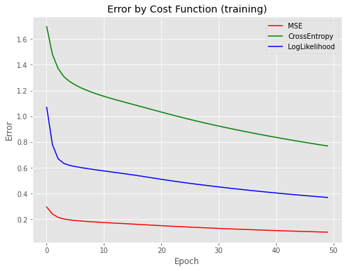

```python
import matplotlib.pyplot as plt
plt.style.use('ggplot')

plt.figure(figsize=(8,6))
plt.plot(mse_train,color='r',label='MSE')
plt.plot(ce_train,color='g',label='CrossEntropy')
plt.plot(loglike_train,color='b',label='LogLikelihood')
plt.title('Error by Cost Function (training)')
plt.xlabel('Epoch')
plt.ylabel('Error')
plt.legend()
plt.show()
```

Three plots, one for each cost function, that shows the error for training vs. test (so that we can inspect for overfitting).

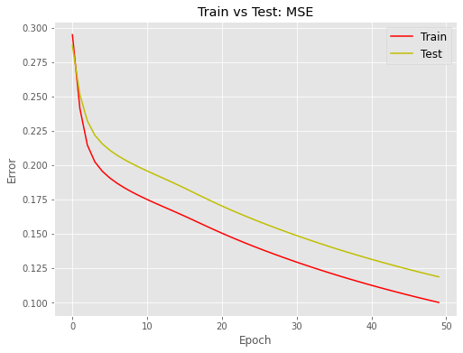

```python
plt.figure(figsize=(8,6))
plt.plot(mse_train,color='r',label='Train')
plt.plot(mse_test,color='y',label='Test')
plt.title('Train vs Test: MSE')
plt.xlabel('Epoch')
plt.ylabel('Error')
plt.legend(prop={'size': 12})
plt.show()
```

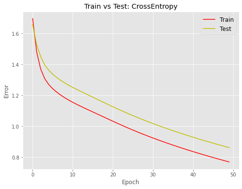

```python
plt.figure(figsize=(8,6))
plt.plot(ce_train,color='r',label='Train')
plt.plot(ce_test,color='y',label='Test')
plt.title('Train vs Test: CrossEntropy')
plt.xlabel('Epoch')
plt.ylabel('Error')
plt.legend(prop={'size': 12})
plt.show()
```

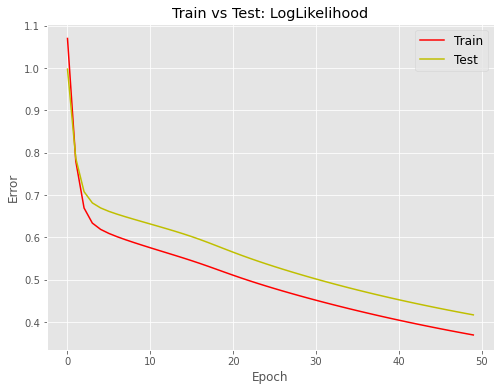

```python
plt.figure(figsize=(8,6))
plt.plot(loglike_train,color='r',label='Train')
plt.plot(loglike_test,color='y',label='Test')
plt.title('Train vs Test: LogLikelihood')
plt.xlabel('Epoch')
plt.ylabel('Error')
plt.legend(prop={'size': 12})
plt.show()
```